# Speed Dating

## Homework10:约会数据集分析

- 2020年5月24日
- 周嘉楠 19210980081

### 分析任务

1. 读入数据，并选出上述表格所示的变量，并确定一个你感兴趣的选题方向；例如：什么因素与两人进一步发展有关？
2. 完成与你的选题相关的 2-3 个描述分析；形式：参考课上讲的描述分析内容；
3. 针对选题目的进行建模，并解读模型的结果；需要包含模型：决策树（需解读模型结果）、Boosting 模型、随机森林、SVM 模型的比较；
4. 结合任务 3-4 的结果，得出你的结论。

```python
# 导入所需库
import pandas as pd
import numpy as np
import seaborn as sns
import statsmodels.api as sm
import matplotlib.pyplot as plt
%matplotlib inline

# 设置表格显示，默认显示所有列
pd.set_option('display.max_columns', 10)
```

# 第1部分 导入数据并进行处理

```python
# 导入数据
data_file = 'Speed Dating Data.csv'
df_full = pd.read_csv(data_file, encoding='ISO-8859-1')
print('====================数据已成功导入====================')
print('文件名称：{}'.format(data_file))
print('数据大小:',df_full.shape[0],'条')
print('表格列头:',df_full.shape[1],'列')

# 将数据类别进行规整分类
personal = ['gender', 'age', 'field', 'field_cd', 'undergra',
           'mn_sat', 'tuition', 'race', 'imprace', 'imprelig', 'from',
           'zipcode', 'income', 'goal', 'date', 'go_out', 'career',
           'career_c', 'sports', 'tvsports', 'exercise', 'dining', 'museums',
           'art', 'hiking', 'gaming', 'clubbing', 'reading', 'tv', 'theater',
           'movies', 'concerts', 'music', 'shopping', 'yoga', 'exphappy',
           'expnum','match_es']

decision = ['match','dec','attr', 'sinc', 'intel', 'fun', 'amb', 'shar', 'like', 'prob','met']

evaluation = ['satis_2', 'length', 'numdat_2']

outcome = ['you_call', 'them_cal', 'date_3', 'numdat_3','num_in_3']
```

```
====================数据已成功导入====================
文件名称：Speed Dating Data.csv
数据大小: 8378 条
表格列头: 195 列
```

导入数据之后我们注意到，在这8378条数据中，有非常多次重复记录，即每个实验对象会和不同人进行多次约会，如果直接进行分析可能 导致偏差的出现，所以需要创建一个新的数据表，其中保证每个试验对象只出现一次。

```python
df = df_full[['iid', 'wave'] + personal + evaluation + outcome].drop_duplicates().copy()
print('====================数据处理完毕====================')
print('数据大小:',df.shape[0],'条')
print('表格列头:',df.shape[1],'列')
df.head()
```

```
====================数据处理完毕====================
数据大小: 551 条
表格列头: 48 列
```

|  | iid | wave | gender | age | field | ... | you_call | them_cal | date_3 | numdat_3 | num_in_3 |
| --- | --- | --- | --- | --- | --- | --- | --- | --- | --- | --- | --- |
| 0 | 1 | 1 | 0 | 21.0 | Law | ... | 1.0 | 1.0 | 0.0 | NaN | NaN |
| 10 | 2 | 1 | 0 | 24.0 | law | ... | 0.0 | 0.0 | 0.0 | NaN | NaN |
| 20 | 3 | 1 | 0 | 25.0 | Economics | ... | NaN | NaN | NaN | NaN | NaN |
| 30 | 4 | 1 | 0 | 23.0 | Law | ... | 0.0 | 0.0 | 0.0 | NaN | NaN |
| 40 | 5 | 1 | 0 | 21.0 | Law | ... | 0.0 | 0.0 | 0.0 | NaN | NaN |

5 rows × 48 columns

# 第2部分 数据探索

## 2.1 参与者画像描述

### 2.1.1 性别、年龄交叉分析

- 在对性别与年龄的交叉分析中，可见绝大部分实验者的年龄集中在26岁左右，其中男性的平均年龄比女性稍大一点，其他方面基本相差无几。

```python
# 性别分布情况
print('====================性别整体分布情况====================')
df['gender'] = df.gender.map({1 : 'Male', 0 : 'Female'}).fillna(df.gender)
df_full['gender'] = df_full.gender.map({1 : 'Male', 0 : 'Female'}).fillna(df_full.gender)
df.gender.value_counts(dropna=False)
```

```
====================性别整体分布情况====================
```

```
Male      277
Female    274
Name: gender, dtype: int64
```

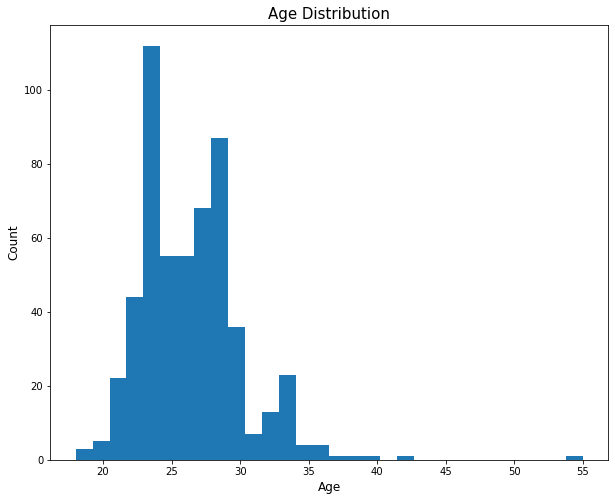

```python
# 年龄分布情况
ax = df.age.hist(bins=30, figsize=(10,8))
ax.set_title('Age Distribution', fontsize=15)
ax.set_xlabel('Age',fontsize=12)
ax.set_ylabel('Count', fontsize=12)
ax.grid(False)
```

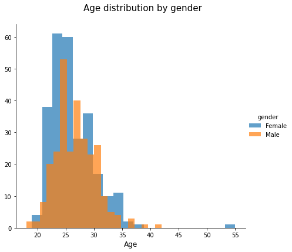

```python
# 分别统计男女性别的年龄分布情况
g = sns.FacetGrid(df, hue='gender', height = 6)
g.map(plt.hist, 'age', alpha= 0.7, bins=20)
g.set_xlabels('Age', fontsize=12)
plt.subplots_adjust(top=0.9)
g.fig.suptitle('Age distribution by gender', fontsize=15)
g.add_legend()
```

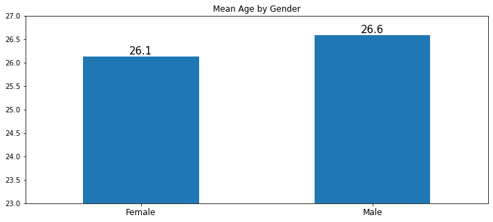

```python
# 性别+年龄分布情况
ax = df[['gender', 'age']].groupby('gender').mean().plot(kind='bar', figsize=(12,5), legend=False,
                                                         title='Mean Age by Gender',ylim=(23,27))
ax.set_xticklabels(['Female', 'Male'], fontsize=12, rotation='horizontal')
ax.set_xlabel('', fontsize=1)
for i in ax.patches:
    ax.text(i.get_x()+.20, i.get_height()+.05, str(round((i.get_height()), 1)), fontsize=15)
```

### 2.1.2 种族、性别、年龄交叉分析

- 对于白种人和其他种族来说，男性比女性多，剩余种族的趋势则相反。
- 对于白种人和其他种族这两个种族，男性的平均年龄要大得多。
- 亚洲女性比男性年龄大。

```python
# 种族分布情况
print('====================种族整体分布情况====================')
df['race'] = df.race.map({1: 'Black', 2: 'White', 3: 'Hispanic',4: 'Asian', 6: 'Other'}).fillna(df.race)
df_full['race'] = df_full.race.map({1: 'Black', 2: 'White', 3: 'Hispanic',4: 'Asian', 6: 'Other'}).fillna(df_full.race)
df_full['race_o'] = df_full.race_o.map({1: 'Black', 2: 'White', 3: 'Hispanic',4: 'Asian', 6: 'Other'}).fillna(df_full.race_o)
df.race.value_counts(dropna=False)
```

```
====================种族整体分布情况====================
```

```
White       304
Asian       136
Hispanic     42
Other        37
Black        26
NaN           6
Name: race, dtype: int64
```

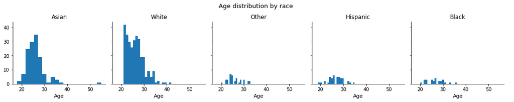

```python
# 种族+年龄分布情况
g = sns.FacetGrid(df, col='race', height=3)
g.map(plt.hist, 'age', bins=20)
axes = g.axes.flatten()
axes[0].set_title("Asian")
axes[1].set_title("White")
axes[2].set_title("Other")
axes[3].set_title("Hispanic")
axes[4].set_title("Black")
g.set_xlabels('Age', fontsize=11)
plt.subplots_adjust(top=0.8)
g.fig.suptitle('Age distribution by race', fontsize=13)
g.add_legend()
```

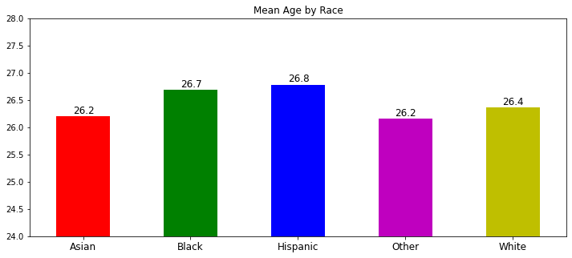

```python
# 种族之间平均年龄分布
ax = df[['race', 'age']].groupby('race').mean().plot(kind='bar', figsize=(12,5), legend=False,
                                                     title='Mean Age by Race',ylim=(24,28), color='rgbmy')
ax.set_xticklabels(['Asian', 'Black', 'Hispanic',  'Other', 'White'], fontsize=12, rotation='horizontal')
ax.set_xlabel('',fontsize=1)
for i in ax.patches:
    ax.text(i.get_x()+.155, i.get_height()+.05,str(round((i.get_height()), 1)), fontsize=12)
```

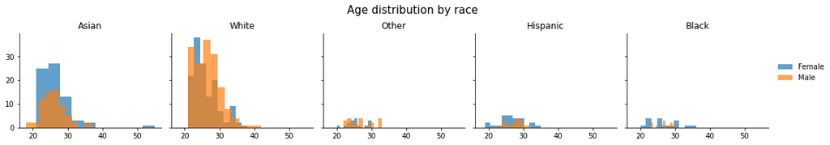

```python
# 种族+性别+年龄分布
g = sns.FacetGrid(df, col='race', hue='gender')
g.map(plt.hist, 'age', alpha= 0.7, bins=10)
g.add_legend()
axes = g.axes.flatten()
axes[0].set_title("Asian")
axes[1].set_title("White")
axes[2].set_title("Other")
axes[3].set_title("Hispanic")
axes[4].set_title("Black")
g.set_xlabels('', fontsize=1)
plt.subplots_adjust(top=0.8)
g.fig.suptitle('Age distribution by race', fontsize=15)
g._legend.set_title('')
```

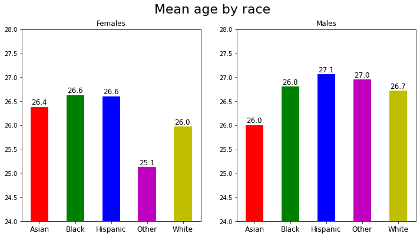

```python
# 种族、性别、平均年龄分布
fig, ax= plt.subplots(1,2, figsize=(12, 6))

df[df.gender=='Female'][['race', 'age']].groupby('race').mean().plot(kind='bar', ax=ax[0], legend=False,
                                                              title='Females', ylim=(24,28),
                                                              color='rgbmy')

df[df.gender=='Male'][['race', 'age']].groupby('race').mean().plot(kind='bar', ax=ax[1], legend=False,
                                                              title='Males', ylim=(24,28),
                                                              color='rgbmy')

ax[0].set_xticklabels(ax[0].get_xticklabels(), fontsize=12, rotation='horizontal')
ax[1].set_xticklabels(ax[1].get_xticklabels(), fontsize=12, rotation='horizontal')
ax[0].set_xlabel('',fontsize=1)
ax[1].set_xlabel('',fontsize=1)

fig.suptitle('Mean age by race', fontsize=22)

for i in ax[0].patches:
    ax[0].text(i.get_x()+.02, i.get_height()+.05, str(round((i.get_height()), 1)), fontsize=12)

for i in ax[1].patches:
    ax[1].text(i.get_x()+.02, i.get_height()+.05, str(round((i.get_height()), 1)), fontsize=12)
```

### 2.1.3 专业、性别交叉分析

- 从事经济、自然科学、英语、法律、社会学的参与者数量最多。
- 工程、金融和数学大多是男性主导的
- 社会、医学、艺术和新闻更多是女性主导的。
- 自然科学、政治科学和电影在两性中所占比例相当。

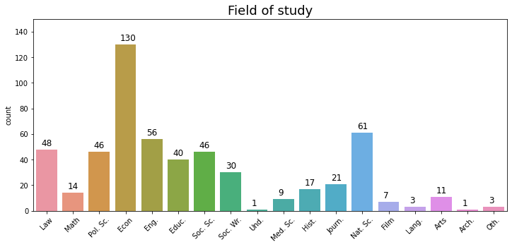

```python
# 专业分布情况
df['field_cd'] = df.field_cd.map({1: 'Law', 2: 'Math', 3: 'Soc. Sc.', 4: 'Med. Sc.',
                                 5: 'Eng.', 6: 'Journ.', 7: 'Hist.', 8: 'Econ', 9: 'Educ.',
                                 10: 'Nat. Sc.', 11: 'Soc. Wr.', 12: 'Und.', 13: 'Pol. Sc.',
                                 14: 'Film', 15: 'Arts', 16:'Lang.', 17: 'Arch.', 18: 'Oth.'}).fillna(df.field_cd)
df_full['field_cd'] = df_full.field_cd.map({1: 'Law', 2: 'Math', 3: 'Soc. Sc.', 4: 'Med. Sc.',
                                 5: 'Eng.', 6: 'Journ.', 7: 'Hist.', 8: 'Econ', 9: 'Educ.',
                                 10: 'Nat. Sc.', 11: 'Soc. Wr.', 12: 'Und.', 13: 'Pol. Sc.',
                                 14: 'Film', 15: 'Arts', 16:'Lang.', 17: 'Arch.', 18: 'Oth.'}).fillna(df_full.field_cd)
df.field_cd.value_counts(dropna=False)


plt.figure(figsize = (12,5))
ax = sns.countplot(x="field_cd", data=df)
plt.title('Field of study', fontsize=18)
ax.set_xticklabels(ax.get_xticklabels(),rotation=45)
plt.ylim(0, 150)
plt.xlabel('')
for i in ax.patches:
    ax.text(i.get_x()+.2, i.get_height()+3, str(round((i.get_height()), 1)), fontsize=12)
```

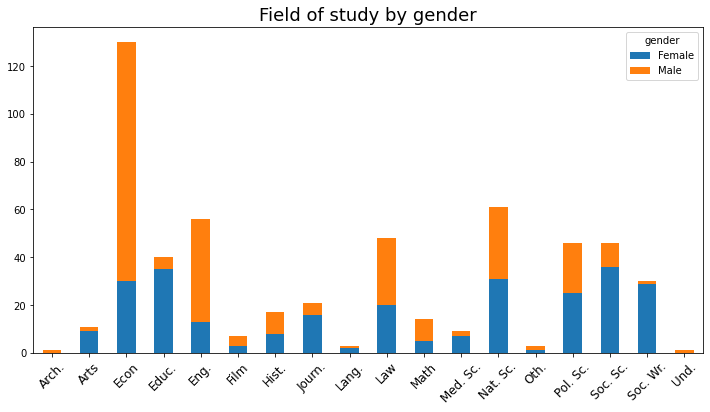

```python
# 专业、性别分布情况
tmp = df[['gender', 'field_cd']].groupby(['field_cd', 'gender']).size().unstack().fillna(0)
ax = tmp.plot(kind='bar', figsize=(12,6), stacked=True)
ax.set_xticklabels(ax.get_xticklabels(), fontsize=12, rotation=45)
ax.set_title('Field of study by gender', fontsize=18)
ax.set_xlabel('',fontsize=1)
```

### 2.1.4 种族、宗教对参与者的重要性

1. 种族：
   - 白人对种族更加看重。
   - 女性比男性对种族更加看重。
   - 如果考虑不同种族之间的性别差异，则白人女性是最看重种族的。
   - 黑人、其他种族的男女观点差异最大。
2. 宗教：
   - 白人对宗教更加看重。
   - 女性比男性对宗教更加看重。
   - 白人女性(以及“其他”女性)比其他人群更重视宗教。
   - 黑人和“其他”种族参与者在不同性别上观点依然存在巨大差异。
   - 拉美裔人似乎相当一致地重视宗教，不论他们的性别。

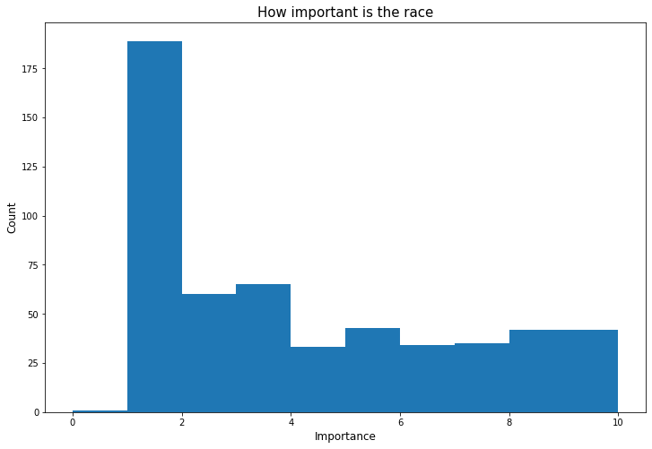

```python
# 参与者对种族重要性的观点分布
ax = df.imprace.hist(bins=10, figsize=(12,8))
ax.set_title('How important is the race', fontsize=15)
ax.set_xlabel('Importance',fontsize=12)
ax.set_ylabel('Count', fontsize=12)
ax.grid(False)
```

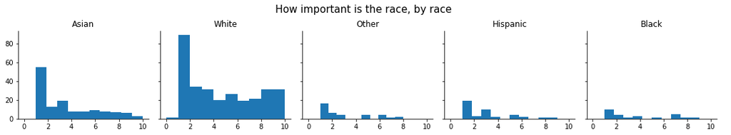

```python
# 不同种族的人中，对种族重要性观点的分布
g = sns.FacetGrid(df, col='race')
g.map(plt.hist, 'imprace', bins=10)
axes = g.axes.flatten()
axes[0].set_title("Asian")
axes[1].set_title("White")
axes[2].set_title("Other")
axes[3].set_title("Hispanic")
axes[4].set_title("Black")
g.set_xlabels('', fontsize=1)
plt.subplots_adjust(top=0.8)
g.fig.suptitle('How important is the race, by race', fontsize=15)
g.add_legend()
```

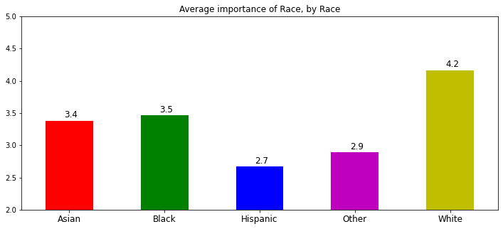

```python
# 不同种族的人中，对种族重要性观点平均分布情况
ax = df[['race', 'imprace']].groupby('race').mean().plot(kind='bar', figsize=(12,5), legend=False,
                                                         title='Average importance of Race, by Race',ylim=(2,5),
                                                         color='rgbmy')
ax.set_xticklabels(ax.get_xticklabels(), fontsize=12, rotation='horizontal')
ax.set_xlabel('',fontsize=1)
for i in ax.patches:
    ax.text(i.get_x()+.2, i.get_height()+.05, str(round((i.get_height()), 1)), fontsize=12)
```

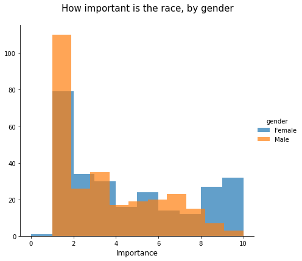

```python
# 不同性别对种族重要性的观点分布
g = sns.FacetGrid(df, hue='gender', height = 6)
g.map(plt.hist, 'imprace', alpha= 0.7, bins=10)
g.set_xlabels('Importance', fontsize=12)
plt.subplots_adjust(top=0.9)
g.fig.suptitle('How important is the race, by gender', fontsize=15)
g.add_legend()
```

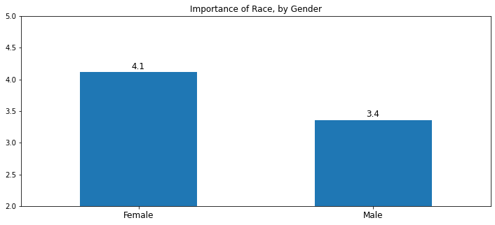

```python
# 不同性别对种族重要性的平均观点分布
ax = df[['gender', 'imprace']].groupby('gender').mean().plot(kind='bar', figsize=(12,5), legend=False,
                                                             title='Importance of Race, by Gender',ylim=(2,5))
ax.set_xticklabels(['Female', 'Male'], fontsize=12, rotation='horizontal')
ax.set_xlabel('',fontsize=1)
for i in ax.patches:
    ax.text(i.get_x()+.22, i.get_height()+.05, str(round((i.get_height()), 1)), fontsize=12)
```

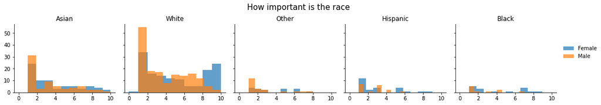

```python
# 不同种族、不同性别对种族重要性的观点分布
g = sns.FacetGrid(df, col='race', hue='gender')
g.map(plt.hist, 'imprace', alpha= 0.7, bins=10)
g.add_legend()
axes = g.axes.flatten()
axes[0].set_title("Asian")
axes[1].set_title("White")
axes[2].set_title("Other")
axes[3].set_title("Hispanic")
axes[4].set_title("Black")
g.set_xlabels('', fontsize=1)
plt.subplots_adjust(top=0.8)
g.fig.suptitle('How important is the race', fontsize=15)
g._legend.set_title('')
```

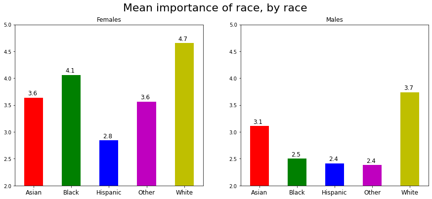

```python
# 不同种族、不同性别对种族重要性的平均观点分布
fig, ax= plt.subplots(1,2, figsize=(15, 6))
df[df.gender=='Female'][['race', 'imprace']].groupby('race').mean().plot(kind='bar', ax=ax[0],
                                                                         legend=False,title='Females', ylim=(2,5),color='rgbmy')
df[df.gender=='Male'][['race', 'imprace']].groupby('race').mean().plot(kind='bar', ax=ax[1],
                                                                       legend=False,title='Males', ylim=(2,5),color='rgbmy')
ax[0].set_xticklabels(ax[0].get_xticklabels(), fontsize=12, rotation='horizontal')
ax[1].set_xticklabels(ax[0].get_xticklabels(), fontsize=12, rotation='horizontal')
ax[0].set_xlabel('',fontsize=1)
ax[1].set_xlabel('',fontsize=1)
fig.suptitle('Mean importance of race, by race', fontsize=22)
for i in ax[0].patches:
    ax[0].text(i.get_x()+.09, i.get_height()+.05, str(round((i.get_height()), 1)), fontsize=12)
for i in ax[1].patches:
    ax[1].text(i.get_x()+.09, i.get_height()+.05, str(round((i.get_height()), 1)), fontsize=12)
```

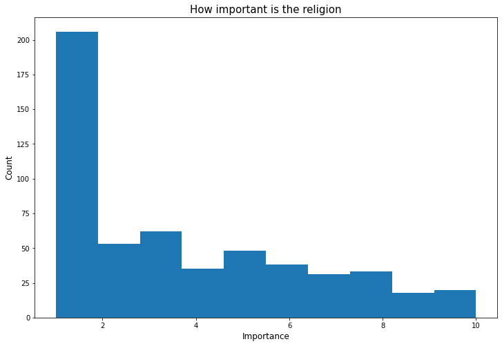

```python
# 参与者对宗教重要性的观点分布
ax = df.imprelig.hist(bins=10, figsize=(12,8))
ax.set_title('How important is the religion', fontsize=15)
ax.set_xlabel('Importance',fontsize=12)
ax.set_ylabel('Count', fontsize=12)
ax.grid(False)
```

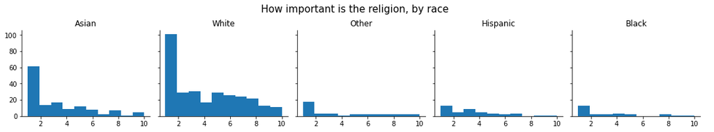

```python
# 不同种族的人中，对宗教重要性观点的分布
g = sns.FacetGrid(df, col='race')
g.map(plt.hist, 'imprelig', bins=10)
g.add_legend()
axes = g.axes.flatten()
axes[0].set_title("Asian")
axes[1].set_title("White")
axes[2].set_title("Other")
axes[3].set_title("Hispanic")
axes[4].set_title("Black")
g.set_xlabels('', fontsize=1)
plt.subplots_adjust(top=0.8)
g.fig.suptitle('How important is the religion, by race', fontsize=15)
```

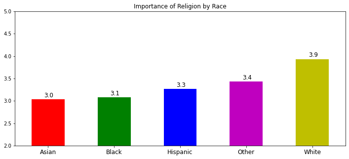

```python
# 不同种族的人中，对宗教重要性平均观点的分布
ax = df[['race', 'imprelig']].groupby('race').mean().plot(kind='bar', figsize=(12,5),
                                                          legend=False,title='Importance of Religion by Race',ylim=(2,5), color='rgbmy')
ax.set_xticklabels(ax.get_xticklabels(), fontsize=12, rotation='horizontal')
ax.set_xlabel('', fontsize=1)
for i in ax.patches:
    ax.text(i.get_x()+.19, i.get_height()+.05, str(round((i.get_height()), 1)), fontsize=12)
```

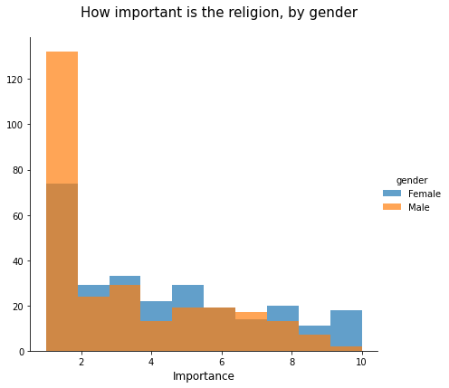

```python
# 不同性别对宗教重要性的观点分布
g = sns.FacetGrid(df, hue='gender', height = 6)
g.map(plt.hist, 'imprelig', alpha= 0.7, bins=10)
g.set_xlabels('Importance', fontsize=12)
plt.subplots_adjust(top=0.9)
g.fig.suptitle('How important is the religion, by gender', fontsize=15)
g.add_legend()
```

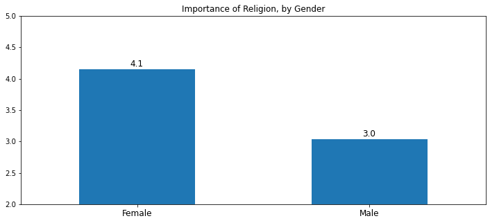

```python
# 不同性别对宗教重要性的平均观点分布
ax = df[['gender', 'imprelig']].groupby('gender').mean().plot(kind='bar', figsize=(12,5),
                                                              legend=False,title='Importance of Religion, by Gender',ylim=(2,5))
ax.set_xticklabels(['Female', 'Male'], fontsize=12, rotation='horizontal')
ax.set_xlabel('', fontsize=1)
for i in ax.patches:
    ax.text(i.get_x()+.22, i.get_height()+.05, str(round((i.get_height()), 1)), fontsize=12)
```

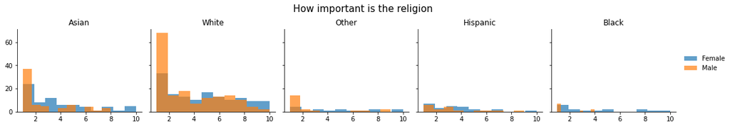

```python
# 不同种族、不同性别对宗教重要性的观点分布
g = sns.FacetGrid(df, col='race', hue='gender')
g.map(plt.hist, 'imprelig', alpha= 0.7, bins=10)
g.add_legend()
axes = g.axes.flatten()
axes[0].set_title("Asian")
axes[1].set_title("White")
axes[2].set_title("Other")
axes[3].set_title("Hispanic")
axes[4].set_title("Black")
g.set_xlabels('', fontsize=1)
plt.subplots_adjust(top=0.8)
g.fig.suptitle('How important is the religion', fontsize=15)
g._legend.set_title('')
```

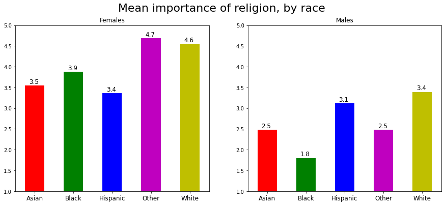

```python
# 不同种族、不同性别对宗教重要性的平均观点分布
fig, ax= plt.subplots(1,2, figsize=(15, 6))

df[df.gender=='Female'][['race', 'imprelig']].groupby('race').mean().plot(kind='bar', ax=ax[0], legend=False,
                                                              title='Females', ylim=(1,5),
                                                              color='rgbmy')

df[df.gender=='Male'][['race', 'imprelig']].groupby('race').mean().plot(kind='bar', ax=ax[1], legend=False,
                                                              title='Males', ylim=(1,5),
                                                              color='rgbmy')
ax[0].set_xticklabels(ax[0].get_xticklabels(), fontsize=12, rotation='horizontal')
ax[1].set_xticklabels(ax[1].get_xticklabels(), fontsize=12, rotation='horizontal')
ax[0].set_xlabel('')
ax[1].set_xlabel('')
fig.suptitle('Mean importance of religion, by race', fontsize=22)
for i in ax[0].patches:
    ax[0].text(i.get_x()+.1, i.get_height()+.05, str(round((i.get_height()), 1)), fontsize=12)

for i in ax[1].patches:
    ax[1].text(i.get_x()+.1, i.get_height()+.05, str(round((i.get_height()), 1)), fontsize=12)
```

## 2.2 参与者兴趣探索

### 2.2.1 热力图

- 男性更倾向于选择有吸引力的女性(attr1_1)
- 女性更倾向于选择有抱负的男性(amb1_1)
- 与最终结果match最相关的不是兴趣爱好，而是对方的决定、态度、以及喜欢程度

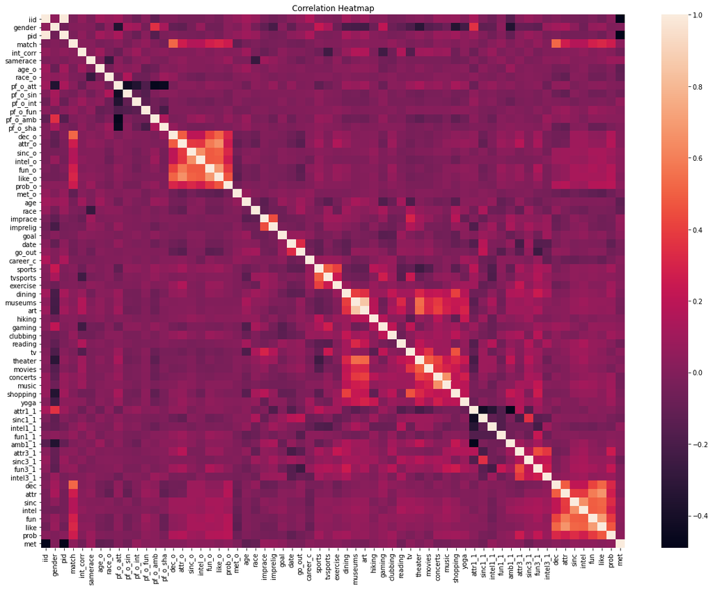

```python
# 重新对数据进行整理
dating = pd.read_csv('Speed Dating Data.csv', encoding="ISO-8859-1")
dating_1 = dating.iloc[:, 11:28]
dating_2 = dating.iloc[:, 30:35]
dating_3 = dating.iloc[:, 39:43]
dating_4 = dating.iloc[:, 45:67]
dating_5 = dating.iloc[:, 69:74]
dating_6 = dating.iloc[:, 87:91]
dating_7 = dating.iloc[:, 97:102]
dating_8 = dating.iloc[:, 104:107]
date = pd.concat([dating.iloc[:, 0],dating.iloc[:, 2],dating_1,dating_2,dating_3,dating_4,dating_5,dating_6,dating_7,dating_8], axis=1)
date2 = date.dropna()
date3 = date2.drop(['field', 'from', 'career'], axis=1)

# 画出热力图
plt.subplots(figsize=(20,15))
ax = plt.axes()
ax.set_title("Correlation Heatmap")
corr = date3.corr()
sns.heatmap(corr,xticklabels=corr.columns.values,yticklabels=corr.columns.values)
```

### 2.2.2 兴趣分布图

- 共进晚餐、看电影、看歌剧是男女约会的共同爱好
- 观看电视运动是男女都比较讨厌的一种活动
- 在购物和瑜伽这两项活动上，女性的偏好要明显大于男性

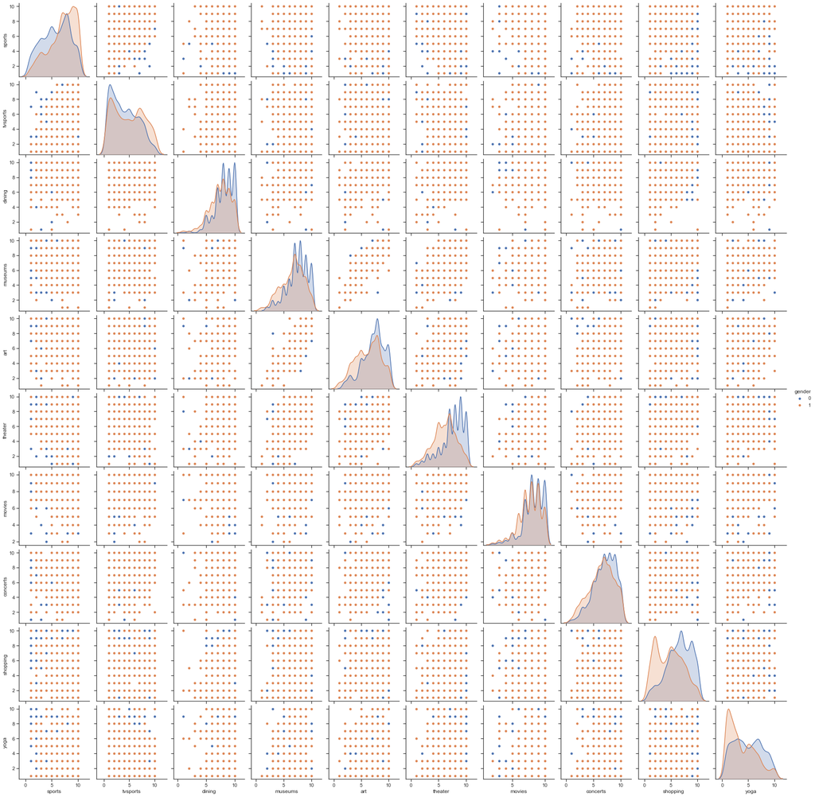

```python
# 针对参与者的兴趣爱好画出分布图
sns.set(style="ticks", color_codes=True)
date_int = pd.concat([date3.iloc[:, 1],date3.iloc[:, [30,31,33,34,35,41,42,43,45,46]]],axis = 1)
g = sns.pairplot(date_int, hue="gender")

# 根据热力图结果，建模时要删除关于兴趣的列
date4 = date3.drop(['sports', 'tvsports', 'exercise', 'dining', 'museums', 'art', 'hiking',
                    'gaming', 'clubbing', 'reading', 'tv', 'theater', 'movies', 'concerts', 'music',
                    'shopping', 'yoga'], axis=1)
```

### 2.2.3 匹配结果的探索

- 女性比男性更容易收到下一次约会的邀请，且这一现象是在统计上显著的。
- 大概有26%的情况是由于单一方面的“一厢情愿”而导致的匹配失败。
- 但是以上情况并不是因为缺乏吸引力造成的。

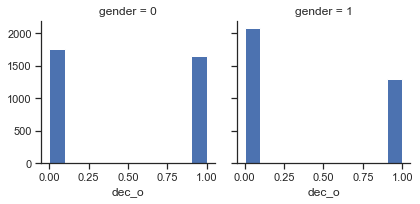

```
卡方检验 p-value： 1.1102230246251565e-16
```

```python
# 不同性别下，对方最终的选择分布情况
sns.set(style="ticks", color_codes=True)
g = sns.FacetGrid(date4, col="gender")
g = g.map(plt.hist, "dec_o")
plt.ticklabel_format(useOffset=False, style='plain')
plt.show()

# 对以上想法进行卡方检验
gender_crosstab = pd.crosstab(index=date4.gender, columns=date4.dec_o)
gender_table = sm.stats.Table(gender_crosstab)
gender_rslt = gender_table.test_nominal_association()
print('卡方检验 p-value：',gender_rslt.pvalue)
```

```python
# 有一方愿意而另一方不愿意的情况
no_love_count = len(date4[(date4['dec_o']==0) & (date4['dec']==1)])
perc_broken_heart = no_love_count / len(date4.index)
print('一厢情愿:',perc_broken_heart*100)
```

```
一厢情愿: 26.040900397234072
```

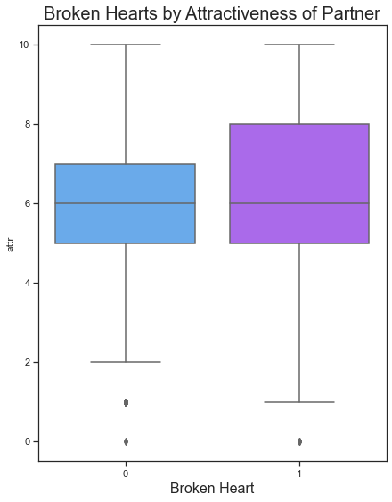

```
卡方检验 p-value： 0.5300021303134917
```

```python
# 以上情况是否由于缺乏吸引力造成的？
date4['url']=np.where(((date4['dec_o']==0) & (date4['dec']==1))|((date4['dec']==0) & (date4['dec_o']==1)),1,0)
plt.figure(figsize=(7,9))
sns.boxplot(x='url', y='attr', data=date4, palette='cool')
plt.title('Broken Hearts by Attractiveness of Partner', fontsize=20)
plt.xlabel('Broken Heart', fontsize=16)
plt.show()

# 对以上想法进行卡方检验
bh_crosstab = pd.crosstab(index=date4.attr, columns=date4.url)
bh_table = sm.stats.Table(bh_crosstab)
bh_rslt = bh_table.test_nominal_association()
print('卡方检验 p-value：',bh_rslt.pvalue)
```

### 2.2.4 对attractiveness, sincerity, intelligence, fun, ambition, liking因素的探索

- 以上几个因素几乎对匹配成功的相关性相差无几；
- 自己对自己吸引力的评价(attr3_1)和对方对你吸引力的评价(attr_o)呈弱相关性，即这两者没什么必然关系；
- 同样地，你自认为有多聪明、忠诚和对方认为你的聪明与忠诚度没什么必然关系；
- 也许以上几个特性在4分钟的快速约会中不会起到什么作用。

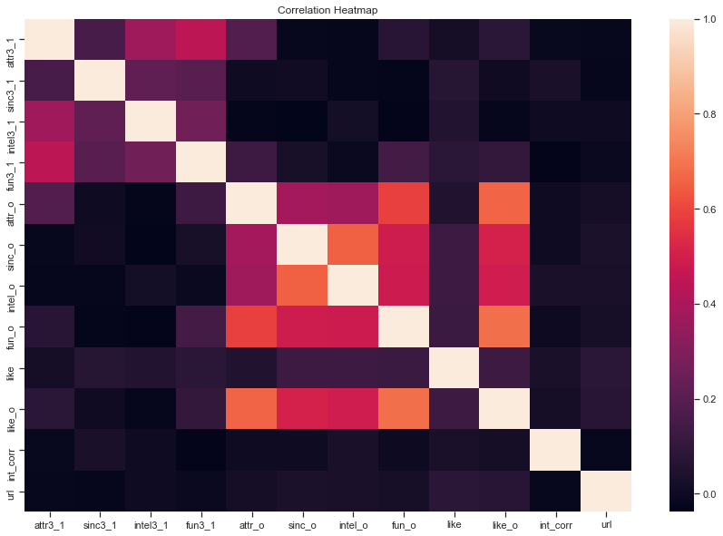

```python
date5 = pd.concat([date4['attr3_1'],date4['sinc3_1'],date4['intel3_1'],date4['fun3_1'],date4['attr_o'],
                   date4['sinc_o'],date4['intel_o'],date4['fun_o'],date4['like'],date4['like_o'],
                   date4['int_corr'],date4['url']],axis=1)
plt.subplots(figsize=(15,10))
ax = plt.axes()
ax.set_title("Correlation Heatmap")
corr = date5.corr()
sns.heatmap(corr, xticklabels=corr.columns.values,yticklabels=corr.columns.values)
```

# 第3部分 建模

```python
from sklearn.model_selection import train_test_split
from sklearn import tree
from sklearn.tree import DecisionTreeClassifier,DecisionTreeRegressor, export_graphviz
from sklearn.svm import SVC
from sklearn.ensemble import RandomForestClassifier
from sklearn.ensemble import GradientBoostingClassifier
from sklearn import metrics
import graphviz
```

```python
# 分割训练集、测试集
X = date4[['attr','attr_o','fun','fun_o','like','like_o','int_corr']]
y = date4['match']
X_train, X_test, y_train, y_test = train_test_split(X, y, test_size=0.3)

my_feature_name = ['attr','attr_o','fun','fun_o','like','like_o','int_corr']
```

```python
# 决策树

model = DecisionTreeClassifier(criterion = 'entropy',random_state=1,max_depth=3)
clf_model = model.fit(X_train,y_train)
predict_train_clf = clf_model.predict(X_train)
predict_test_clf = clf_model.predict(X_test)
print('Training Accuracy:', metrics.accuracy_score(y_train, predict_train_clf))
print('Validation Accuracy:', metrics.accuracy_score(y_test, predict_test_clf))
print('参数权重：',[*zip(my_feature_name,clf_model.feature_importances_)])

# 画出决策树
dot_data = tree.export_graphviz(clf_model
                                ,feature_names = my_feature_name
                                ,class_names=["不匹配","匹配"]
                                ,filled=True
                                ,rounded=True
                               )
graph = graphviz.Source(dot_data)
graph
```

```
Training Accuracy: 0.83876392684465
Validation Accuracy: 0.8348039215686275
参数权重： [('attr', 0.014372953798663305), ('attr_o', 0.053089820458201806), ('fun', 0.0), ('fun_o', 0.0), ('like', 0.5137247727599484), ('like_o', 0.4188124529831866), ('int_corr', 0.0)]
```

[figure not shown]

### 决策树模型总结：

1. 决策树模型在训练数据集上的正确率达到了83.88%，在验证数据集上的正确率达到了83.48%
2. 决策树模型认为最重要的参数有2个，即双方相互的喜欢程度，分别占了0.5137和0.4188，基本对结果起到了决定性作用
3. 从上面决策树的可视化图形中可以看到，最终匹配的条件为：
   - 你喜欢对方的程度大于6.25
   - 对方喜欢你的程度大于6.25
   - 对方认为你的吸引力大于7.75

```python
# Boosting 模型：xgboost模型
model = GradientBoostingClassifier()
xgb_model = model.fit(X_train, y_train)
predict_train_xgb = xgb_model.predict(X_train)
predict_test_xgb = xgb_model.predict(X_test)
print('Training Accuracy:', metrics.accuracy_score(y_train, predict_train_xgb))
print('Validation Accuracy:', metrics.accuracy_score(y_test, predict_test_xgb))
print('参数权重：',[*zip(my_feature_name,xgb_model.feature_importances_)])
```

```
Training Accuracy: 0.8669329409291571
Validation Accuracy: 0.8450980392156863
参数权重： [('attr', 0.14077047997497472), ('attr_o', 0.16034617339306492), ('fun', 0.058325392103852215), ('fun_o', 0.07451691789027678), ('like', 0.26721772340512684), ('like_o', 0.2501572107326575), ('int_corr', 0.04866610250004686)]
```

### XGBoost模型总结：

1. XGBoost模型在训练数据集上的正确率达到了86.69%，在验证数据集上的正确率达到了84.51%
2. XGBoost模型对这些特征权重的分配比较均匀，其中最重要的依然是双方相互的喜欢程度，分别占了0.2672和0.2502，其次重要的是双方相互的吸引力，分别占了0.1408和0.1603

```python
# 随机森林模型
model = RandomForestClassifier(random_state=0)
rf_model = model.fit(X_train, y_train)
predict_train_rf = rf_model.predict(X_train)
predict_test_rf = rf_model.predict(X_test)
print('Training Accuracy:', metrics.accuracy_score(y_train, predict_train_rf))
print('Validation Accuracy:', metrics.accuracy_score(y_test, predict_test_rf))
print('参数权重：',[*zip(my_feature_name,rf_model.feature_importances_)])
```

```
Training Accuracy: 0.9997897834769813
Validation Accuracy: 0.8426470588235294
参数权重： [('attr', 0.12476231072539805), ('attr_o', 0.12318938804081746), ('fun', 0.11431555267190505), ('fun_o', 0.11468405067731285), ('like', 0.12883559179423046), ('like_o', 0.12613419827981245), ('int_corr', 0.26807890781052374)]
```

```python
# SVM模型
svm_model = SVC(kernel = "linear").fit(X_train, y_train)
predict_train_svm = svm_model.predict(X_train)
predict_test_svm = svm_model.predict(X_test)
print('Training Accuracy:', metrics.accuracy_score(y_train, predict_train_svm))
print('Validation Accuracy:', metrics.accuracy_score(y_test, predict_test_svm))
print('参数权重：',svm_model.coef_)
```

```
Training Accuracy: 0.8250998528484339
Validation Accuracy: 0.8254901960784313
参数权重： [[0.00053295 0.00058489 0.00022754 0.00023148 0.00069404 0.00061594
  0.00052808]]
```